# Reinforcement Learning

Abe Vos

April 2022

# Introductie

## Korte terugblik

- Supervised learning
- Input/output paren (gelabelde data)
- Generaliseer naar nieuwe situaties

## Reinforcement Learning

- Leren door interactie (trial & error)
- Maximaliseer beloning
- Exploration & exploitation

# Reinforcement Learning

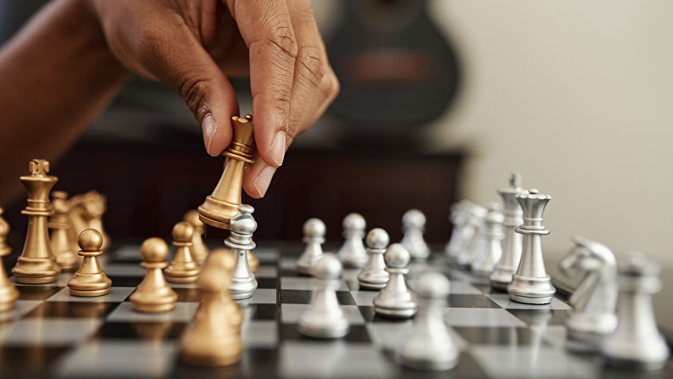

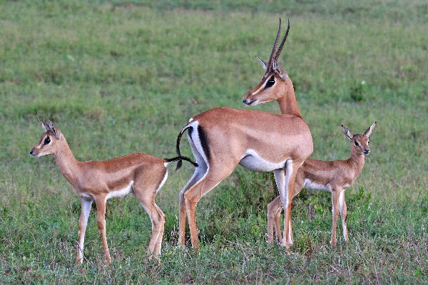

[figure not shown]

## Eigenschappen

- *Agent* gebruikt *interactie*
- *Agent* bereikt een *doel*
- Houd rekening met *onzekerheid*

## Agent en Interactie

- Agent voert acties uit
- Kies acties a.d.h.v. observaties
- Acties veranderen omgeving → nieuwe observatie

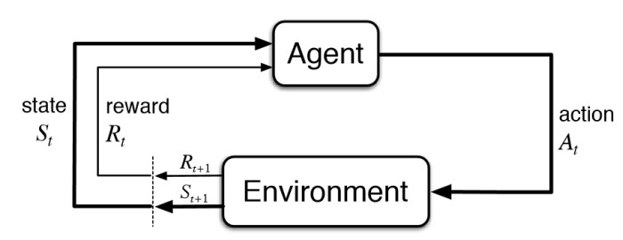

## Doel

- Gewenste uitkomst
- Niet altijd vanzelfsprekend

CoastRunners

[figure not shown]

## Onzekerheid

- Effecten van acties zijn niet altijd voorspelbaar
- Observaties van de staat zijn niet altijd volledig

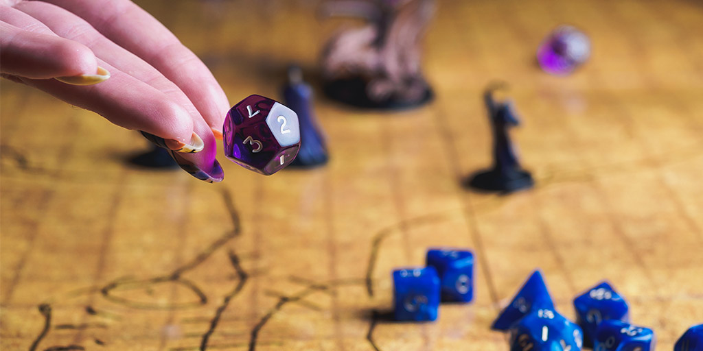

Acties in DND hebben een onzekere uitkomst

[figure not shown]

Strategiespellen hebben onzekere observaties

# Intermezzo: kansrekening

## Randomness

- Maakt een situatie onzeker
- Spelers gebruiken kansrekening om te redeneren over onzekerheid

## Stochastische variabele

- Variabele met onzekere waarde
- Functies van stochasten zijn ook stochastisch
- Notatie met hoofdletter (bijv.: $X$)
  - Uitkomst is kleine letter (bijv.: $x$)

Discreet en continu

- Discrete stochasten: telbaar
  - `random.randint()`
- Continue stochasten: ontelbaar
  - `random.random()`

Kanswaardes

- Elke uitkomst van een stochast heeft een kanswaarde: $p(X=x)$
- Kansverdeling: functie van uitkomst naar kanswaarde
- Twee voorwaarden:
  - $p(X=x)\geq0, \forall x\in\mathcal{X}$
  - $\sum_{x\in\mathcal{X}} p(X=x)=1$

Dobbelsteen

| $x$ | $p(X=x)$ |
| --- | --- |
| 1 | $\frac{1}{6}$ |
| 2 | $\frac{1}{6}$ |
| 3 | $\frac{1}{6}$ |
| 4 | $\frac{1}{6}$ |
| 5 | $\frac{1}{6}$ |
| 6 | $\frac{1}{6}$ |

Normaalverdeling

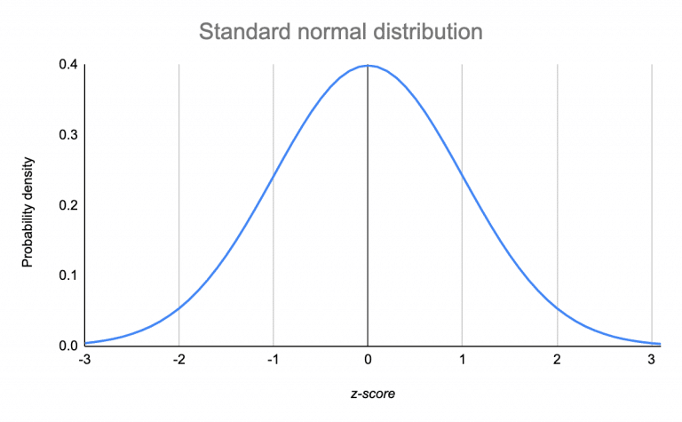

$p(X=x;\mu,\sigma)=\frac{1}{\sigma\sqrt{2\pi}}e^{-\frac{1}{2}\left(\frac{x-\mu}{\sigma}\right)^2}$

Steekproeven/sampling

Simultane kansverdeling

- Kansverdeling voor twee of meer variabelen $p(X, Y)$
- “Wat is de kans om twee zessen te gooien met twee dobbelstenen?”
  - Niet hetzelfde als de kans om een 12 te gooien met twee dobbelstenen!
- Kansverdeling van twee onafhankelijke gebeurtenissen: $p(X, Y)=p(X)p(Y)$

Voorwaardelijke kansverdeling

- Kansverdeling voor een stochast nadat we een andere stochast hebben geobserveerd: $p(X\vert Y)$
- “Wat is de kans om een totaal van zeven te gooien met twee dobbelstenen, gegeven dat de eerste dobbelsteen een 4 rolde?”

Onafhankelijke gebeurtenissen

- Uitkomst van een stochast heeft geen invloed op andere stochasten
- $p(X|Y)=p(X)$
- Twee dobbelstenen
  - Eerste worp heeft geen invloed op tweede worp
  - Eerst worp heeft wel invloed op de som van uitkomsten

Eigenschappen van stochasten

- Verwachte waarde
- Variantie/standaard deviatie

Verwachte waarde

- $\mathbb{E}[X]=\sum_{x\in\mathcal{X}}xp(X=x)$
- Gemiddelde uitkomst over een grote hoeveelheid uitkomsten
- Verwachting hoeft geen mogelijke uitkomst te zijn
  - Voorbeeld: verwachte uitkomst van een dobbelsteen is 3.5

Variantie

- $\text{Var}(X)=\mathbb{E}[(X-\mu)^2]=\mathbb{E}[X^2]-\mathbb{E}[X]^2$
  - $\text{Var}(X)=\sum_{x\in\mathcal{X}}p(X=x)(x-\mathbb{E}[X])^2$
- Gemiddeld verschil met gemiddelde

# Scope

## Elementen van de agent

- Beleid
- Beloning
- Waarde funcie

## Beleid

- Gekozen actie $a$ voor elke staat $s$: $\pi(a\vert s)$
- Kan een kansverdeling zijn
- Stochastische acties zijn nuttig voor verkenning

## Beloning

- Doel is uitgedrukt als beloningssignaal
- Beloningen bij elke staat
- Totale beloning = som van alle beloningen

## Waarde-functie

- Geeft “waarde” voor elke staat
- Waarde is de verwachte totale beloning in de toekomst
- Beloningen zijn direct; waarde is voor de lange termijn
- Waarde wordt geleerd en bepaalt het beleid

## Finite Markov Decision Process

- Model voor beslissingsproblemen
- Verzameling van staten $s\in \mathcal{S}$ en acties in die staten $a\in\mathcal{A}(s),\forall s\in \mathcal{S}$
- Overgangsfunctie $p(S_{t+1}=s'\vert S_t=s, A_t=a)$
- Beloningsfunctie $R(s, a, s')$

## Discount factor

- Waarde tussen 0 en 1
- Bepaalt invloed van beloningen in de toekomst op de waarde van het heden
- $\gamma=1$; beloningen in de toekomst tellen even zwaar mee als directe beloningen
- $\gamma=0$; alleen de directe beloning doet ertoe
- Hyperparameter in veel methodes

## Optimalisatie objectief

- Functie die we willen maximaliseren
- Totale beloning: $G=\sum_{t=0}^\infty \gamma^t R(S_{t+1}, A_t, S_t)$
  - Elke stap krijgen we een actie van $\pi(A_t\vert S_t)$
  - En een nieuwe staat van $p(S_{t+1}\vert A_t, S_t)$
  - $G$ is stochastisch, omdat $S_{t+1}$ dat ook is
- Objectief: verwachte totale beloning $\max_{\pi}\mathbb{E}[G]$

# Dynamic Programming

Wat leren we nou eigenlijk?

- Maximaliseer verwachte totale beloning
- Verwachte totale beloning wordt bepaalt door beleid
- Beleid wordt bepaalt door waarde-functie

Aanpakken van RL

- Maak een schatting van waarde-functie
  - Beleid kiest acties die tot hoogste waarde leiden
- Zoek direct naar een beleid

Policy Iteration

- Bereken de waarde-functie a.d.h.v. een beleid
  - Update daarna het beleid met de berekende waarde-functie
- Policy Evaluation & Policy Improvement
- Deterministisch beleid $a=\pi(s)$

Policy Evaluation benodigdheden

- Arbitraire beleidsfunctie $/pi(s)$
- Arbitraire waarde-functie $V(s)$
  - Als er een eindstaat $s_\text{terminal}$ bestaat, dan moet $V(s_\text{terminal})=0$
- Maximale verandering $\Delta=0$
  - Houdt *convergentie* bij
- Kleine drempelwaarde $\theta>0$

Policy Evaluation

- Ga elke staat $s\in\mathcal{S}$ langs
- $V_\text{oud}\leftarrow V(s)$
- $V(s) \leftarrow \sum_{s',r}p(s',r\vert s,\pi(s))[r+\gamma V(s')]$
- $V(s) \leftarrow \sum_a\pi(a\vert s)\sum_{s',r}p(s',r\vert s,a)[r+\gamma V(s')]$
- Update $\Delta\leftarrow\max(\Delta,\left|V_\text{oud}-V(s)\right|)$
- Herhaal totdat $\Delta<\theta$

Gridworld

- Raster
- Agent kan omhoog, omlaag en opzij bewegen
- Staat is (x, y) positie van agent
- Elke overgang geeft een beloning
  - Acties die de agent van het bord af leiden, krijgen negatieve beloning
  - Eindstaten kunnen met beloningen aangegeven worden

[figure not shown]

Gridworld voorbeeld

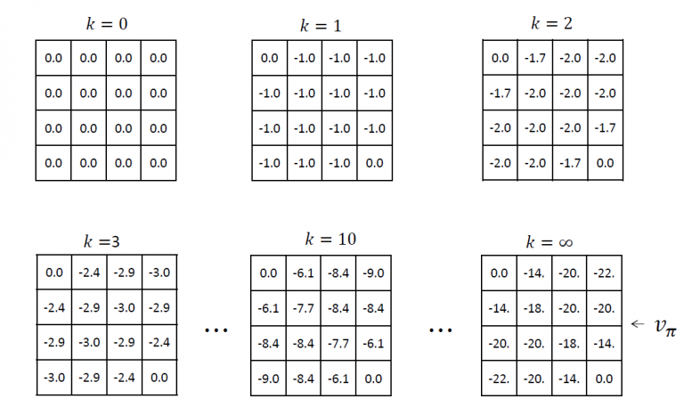

Policy Evaluation

Policy Improvement

- Gebruik $V(s)$ van Policy Evaluation om $\pi(s)$ te updaten
- Voor elke $s\in\mathcal{S}$
  - Sla de actie $\pi(s)$ tijdelijk op
  - Bereken $\sum_{s',r}p(s',r\vert s,a)[r+\gamma V(s')]$ voor elke actie
  - Stel $\pi(s)$ in op de actie met de hoogste waarde

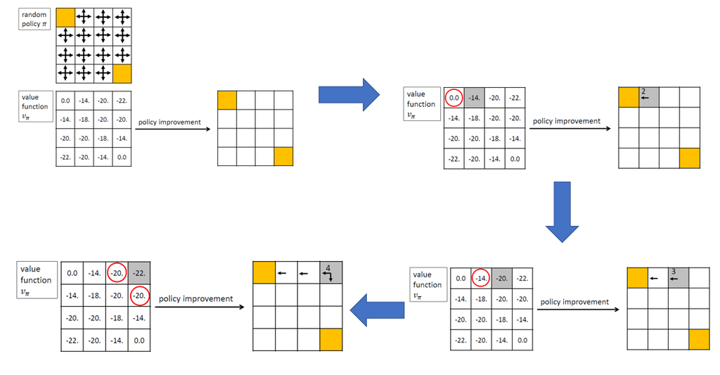

Policy Improvement

Policy Iteration

- Update $V(s)$ met Policy Evaluation
- Update $\pi(s)$ met Policy Improvement
- Herhaal totdat het beleid gelijk blijft voor elke staat
  - Dit gebeurt wanneer het beleid optimaal is

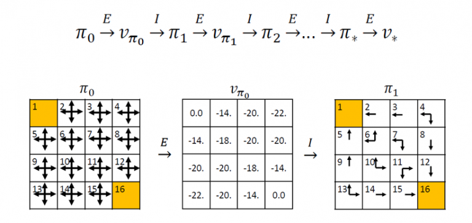

Policy Iteration

Value Iteration

- Policy Evaluation kan traag zijn
- Combineer Evaluation en Improvement stappen
- Vervang de update stap van policy evaluation
- $V(s)\leftarrow\max_a\sum_{s',r}p(s',r\vert s,a)[r+\gamma V(s')]$
- 1 “Evaluation” en 1 “Improvement”

Tekortkomingen

- Zijn afhankelijk van de overgangsfunctie $p(s',r\vert s,a)$
- Moeten *alle* staten langs gaan
  - Vier-op-een-rij heeft $4531985219092$ staten

# Huiswerk

## Github

- https://github.com/AbeVos/self-learning-ai-2022
- Huiswerk en slides
- Elk college geupdate

## Eerste opdracht

- Programmeren en opdrachten
- Instructies voor inleveren in de opdracht
- Deadline 12 mei, 23:59u

## Vragen/ziekmeldingen/etc.

- abe_vos@msn.com
- Discord?